```
Downloading mplfinance-0.12.10b0-py3-none-any.whl (75 kB)
   ━━━━━━━━━━━━━━━━━━━━━━━━━━━━━━━━━━━━━━━━ 75.0/75.0 kB 3.0 MB/s eta 0:00:00
```

|  | Source.Name | ticker | time | open | high | low | close | Volume |
| --- | --- | --- | --- | --- | --- | --- | --- | --- |
| 0 | ABSA.csv | ABSA | 14/09/2020 | 9.80 | 10.0 | 9.80 | 9.84 | 825100 |
| 1 | ABSA.csv | ABSA | 21/09/2020 | 9.80 | 10.0 | 9.60 | 9.98 | 4024700 |
| 2 | ABSA.csv | ABSA | 28/09/2020 | 10.20 | 10.8 | 9.66 | 9.80 | 4160000 |
| 3 | ABSA.csv | ABSA | 05/10/2020 | 9.82 | 9.9 | 9.36 | 9.44 | 2574100 |
| 4 | ABSA.csv | ABSA | 12/10/2020 | 9.40 | 9.8 | 9.30 | 9.80 | 316300 |

|  | ticker | time | open | high | low | close | Volume |
| --- | --- | --- | --- | --- | --- | --- | --- |
| 0 | ABSA | 14/09/2020 | 9.80 | 10.0 | 9.80 | 9.84 | 825100 |
| 1 | ABSA | 21/09/2020 | 9.80 | 10.0 | 9.60 | 9.98 | 4024700 |
| 2 | ABSA | 28/09/2020 | 10.20 | 10.8 | 9.66 | 9.80 | 4160000 |
| 3 | ABSA | 05/10/2020 | 9.82 | 9.9 | 9.36 | 9.44 | 2574100 |
| 4 | ABSA | 12/10/2020 | 9.40 | 9.8 | 9.30 | 9.80 | 316300 |

# Market Data Understanding

**Open:** The price at the first trade on Monday morning.

**High (The Bulls' Strength):** The highest point the stock reached during the week.

**Low (The Bears' Strength):** The lowest point the stock touched.

**Close (The Settlement):** The most critical piece of data. It is the final price on Friday.

**Volume (The Conviction):** The total sum of all shares that changed hands from Monday to Friday.

# Data Inspection

```
(2693, 7)
```

|  | open | high | low | close | Volume |
| --- | --- | --- | --- | --- | --- |
| count | 2693.000000 | 2693.000000 | 2693.000000 | 2693.000000 | 2.693000e+03 |
| mean | 64.189859 | 65.981047 | 62.391250 | 64.325761 | 2.299926e+06 |
| std | 64.531850 | 66.342494 | 62.856232 | 64.805031 | 4.253686e+06 |
| min | 8.600000 | 8.800000 | 8.500000 | 8.700000 | 1.000000e+02 |
| 25% | 21.100000 | 21.800000 | 20.500000 | 21.250000 | 1.523000e+05 |
| 50% | 43.500000 | 44.750000 | 42.100000 | 43.500000 | 5.641000e+05 |
| 75% | 80.500000 | 83.000000 | 78.000000 | 80.000000 | 2.503743e+06 |
| max | 364.000000 | 370.000000 | 345.000000 | 365.000000 | 5.510190e+07 |

```
<class 'pandas.core.frame.DataFrame'>
RangeIndex: 2693 entries, 0 to 2692
Data columns (total 7 columns):
 #   Column  Non-Null Count  Dtype
---  ------  --------------  -----
 0   ticker  2693 non-null   object
 1   time    2693 non-null   object
 2   open    2693 non-null   float64
 3   high    2693 non-null   float64
 4   low     2693 non-null   float64
 5   close   2693 non-null   float64
 6   Volume  2693 non-null   int64
dtypes: float64(4), int64(1), object(2)
memory usage: 147.4+ KB
```

|  | 0 |
| --- | --- |
| ticker | object |
| time | datetime64[ns] |
| open | float64 |
| high | float64 |
| low | float64 |
| close | float64 |
| Volume | int64 |

**dtype:** object

# Data Cleaning

|  | 0 |
| --- | --- |
| ticker | 0 |
| time | 0 |
| open | 0 |
| high | 0 |
| low | 0 |
| close | 0 |
| Volume | 0 |

**dtype:** int64

# KCB Closing Price (5 Years)

[figure not shown]

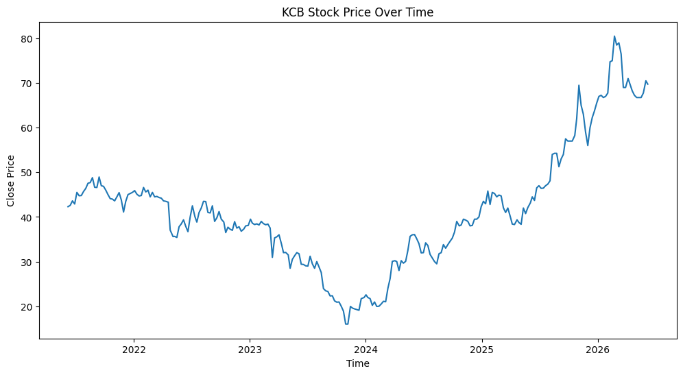

# Static Volatility

- Static volatility refers to a measure of price fluctuation that assumes the volatility of an asset remains constant or fixed over a given period.

-In quantitative finance and data science, Static Volatility ($\sigma$) is calculated as the standard deviation of logarithmic returns.

**The Formula(Logarithmic Returns)**

$$r_t = \ln\left(\frac{P_t}{P_{t-1}}\right)$$

$P_t$: The closing price at the end of the current week.

$P_{t-1}$: The closing price at the end of the previous week. $\ln$: The natural logarithm.

# `static_volatility = log_returns.std()`

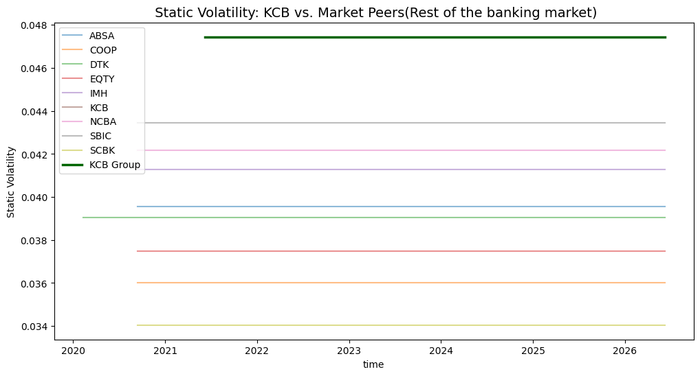

# Dynamic Volatility (Rolling Window)

Dynamic Volatility (often called "Rolling" or "Realized" Volatility) is the measure of an asset's price risk as it changes over time.

**The Formula**

$$\sigma_{rolling} = \sqrt{\frac{\sum_{i=t-n+1}^{t} (r_i - \bar{r}_n)^2}{n - 1}}$$Where:$n$: The window size (e.g., $4$ weeks).

$r_i$: The log return for a specific week within the window.

$\bar{r}_n$: The mean (average) of the log returns only within that window.

$t$: The current point in time.

|  | ticker | time | open | high | low | close | Volume | log_return | static_volatility | rolling_vol |
| --- | --- | --- | --- | --- | --- | --- | --- | --- | --- | --- |
| 0 | ABSA | 2020-09-14 | 9.80 | 10.0 | 9.80 | 9.84 | 825100 | 0.014127 | 0.039545 | 0.025455 |
| 1 | ABSA | 2020-09-21 | 9.80 | 10.0 | 9.60 | 9.98 | 4024700 | 0.014127 | 0.039545 | 0.025455 |
| 2 | ABSA | 2020-09-28 | 10.20 | 10.8 | 9.66 | 9.80 | 4160000 | -0.018201 | 0.039545 | 0.025455 |
| 3 | ABSA | 2020-10-05 | 9.82 | 9.9 | 9.36 | 9.44 | 2574100 | -0.037426 | 0.039545 | 0.025455 |
| 4 | ABSA | 2020-10-12 | 9.40 | 9.8 | 9.30 | 9.80 | 316300 | 0.037426 | 0.039545 | 0.033308 |

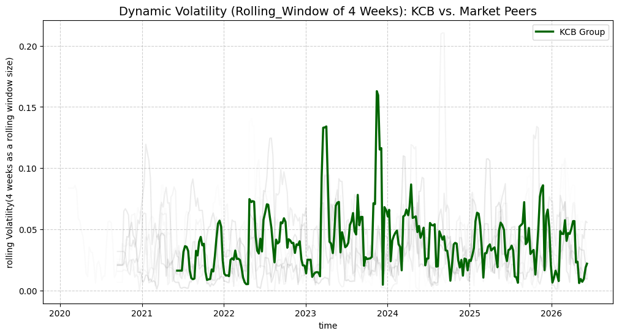

# Insights From KCB High Static & Dynamic Volatility

```
80.5
```

```
15.0
```